# Store24 (A): Managing Employee Retention

Sahil kumar

February 12, 2018

# Task 4c Loading and Summary of Dataset

```r
setwd("G:\\Intern - IIM Lucknow")
store <-read.csv(paste("Store24.csv",sep=""))
View(store)

summary(store)
```

```
##      store          Sales             Profit          MTenure
##  Min.   : 1.0   Min.   : 699306   Min.   :122180   Min.   :  0.00
##  1st Qu.:19.5   1st Qu.: 984579   1st Qu.:211004   1st Qu.:  6.67
##  Median :38.0   Median :1127332   Median :265014   Median : 24.12
##  Mean   :38.0   Mean   :1205413   Mean   :276314   Mean   : 45.30
##  3rd Qu.:56.5   3rd Qu.:1362388   3rd Qu.:331314   3rd Qu.: 50.92
##  Max.   :75.0   Max.   :2113089   Max.   :518998   Max.   :277.99
##     CTenure              Pop             Comp          Visibility
##  Min.   :  0.8871   Min.   : 1046   Min.   : 1.651   Min.   :2.00
##  1st Qu.:  4.3943   1st Qu.: 5616   1st Qu.: 3.151   1st Qu.:3.00
##  Median :  7.2115   Median : 8896   Median : 3.629   Median :3.00
##  Mean   : 13.9315   Mean   : 9826   Mean   : 3.788   Mean   :3.08
##  3rd Qu.: 17.2156   3rd Qu.:14104   3rd Qu.: 4.230   3rd Qu.:4.00
##  Max.   :114.1519   Max.   :26519   Max.   :11.128   Max.   :5.00
##     PedCount         Res          Hours24       CrewSkill
##  Min.   :1.00   Min.   :0.00   Min.   :0.00   Min.   :2.060
##  1st Qu.:2.00   1st Qu.:1.00   1st Qu.:1.00   1st Qu.:3.225
##  Median :3.00   Median :1.00   Median :1.00   Median :3.500
##  Mean   :2.96   Mean   :0.96   Mean   :0.84   Mean   :3.457
##  3rd Qu.:4.00   3rd Qu.:1.00   3rd Qu.:1.00   3rd Qu.:3.655
##  Max.   :5.00   Max.   :1.00   Max.   :1.00   Max.   :4.640
##     MgrSkill        ServQual
##  Min.   :2.957   Min.   : 57.90
##  1st Qu.:3.344   1st Qu.: 78.95
##  Median :3.589   Median : 89.47
##  Mean   :3.638   Mean   : 87.15
##  3rd Qu.:3.925   3rd Qu.: 99.90
##  Max.   :4.622   Max.   :100.00
```

# Task 4d

# 1.Use R to measure the mean and standard deviation of Profit.

```r
mean(store$Profit)
```

```
## [1] 276313.6
```

```r
sd(store$Profit)
```

```
## [1] 89404.08
```

# 2.Use R to measure the mean and standard deviation of MTenure.

```r
mean(store$MTenure)
```

```
## [1] 45.29644
```

```r
sd(store$MTenure)
```

```
## [1] 57.67155
```

# 3.Use R to measure the mean and standard deviation of CTenure.

```r
mean(store$CTenure)
```

```
## [1] 13.9315
```

```r
sd(store$CTenure)
```

```
## [1] 17.69752
```

# Task 4e Sorting and Subsetting data in R

```r
attach(mtcars)
View(mtcars)
newdata <- mtcars[order(mpg),] # sort by mpg (ascending)
View(newdata)
newdata[1:5,] # see the first 5 rows
```

```
##                      mpg cyl disp  hp drat    wt  qsec vs am gear carb
## Cadillac Fleetwood  10.4   8  472 205 2.93 5.250 17.98  0  0    3    4
## Lincoln Continental 10.4   8  460 215 3.00 5.424 17.82  0  0    3    4
## Camaro Z28          13.3   8  350 245 3.73 3.840 15.41  0  0    3    4
## Duster 360          14.3   8  360 245 3.21 3.570 15.84  0  0    3    4
## Chrysler Imperial   14.7   8  440 230 3.23 5.345 17.42  0  0    3    4
```

```r
newdata <- mtcars[order(-mpg),] # sort by mpg (descending)
View(newdata)
newdata[1:5,] # see the first 5 rows
```

```
##                 mpg cyl disp  hp drat    wt  qsec vs am gear carb
## Toyota Corolla 33.9   4 71.1  65 4.22 1.835 19.90  1  1    4    1
## Fiat 128       32.4   4 78.7  66 4.08 2.200 19.47  1  1    4    1
## Honda Civic    30.4   4 75.7  52 4.93 1.615 18.52  1  1    4    2
## Lotus Europa   30.4   4 95.1 113 3.77 1.513 16.90  1  1    5    2
## Fiat X1-9      27.3   4 79.0  66 4.08 1.935 18.90  1  1    4    1
```

```r
detach(mtcars)
```

# Task 4f

# 4.Use R to print the {StoreID, Sales, Profit, MTenure, CTenure} of the top 10 most profitable stores.

```r
attach(store)
newdata<-store[order(-Profit),]
View(newdata)
newdata[1:10,1:5]
```

```
##    store   Sales Profit   MTenure    CTenure
## 74    74 1782957 518998 171.09720  29.519510
## 7      7 1809256 476355  62.53080   7.326488
## 9      9 2113089 474725 108.99350   6.061602
## 6      6 1703140 469050 149.93590  11.351130
## 44    44 1807740 439781 182.23640 114.151900
## 2      2 1619874 424007  86.22219   6.636550
## 45    45 1602362 410149  47.64565   9.166325
## 18    18 1704826 394039 239.96980  33.774130
## 11    11 1583446 389886  44.81977   2.036961
## 47    47 1665657 387853  12.84790   6.636550
```

# 5.Use R to print the {StoreID, Sales, Profit, MTenure, CTenure} of the bottom 10 least profitable stores.

```r
newdata[66:75,1:5]
```

```
##    store   Sales Profit     MTenure   CTenure
## 37    37 1202917 187765  23.1985000  1.347023
## 61    61  716589 177046  21.8184200 13.305950
## 52    52 1073008 169201  24.1185600  3.416838
## 54    54  811190 159792   6.6703910  3.876797
## 13    13  857843 152513   0.6571813  1.577002
## 32    32  828918 149033  36.0792600  6.636550
## 55    55  925744 147672   6.6703910 18.365500
## 41    41  744211 147327  14.9180200 11.926080
## 66    66  879581 146058 115.2039000  3.876797
## 57    57  699306 122180  24.3485700  2.956879
```

# Task 4g Scatter Plots

```r
library(car)
```

# 6.Use R to draw a scatter plot of Profit vs. MTenure.

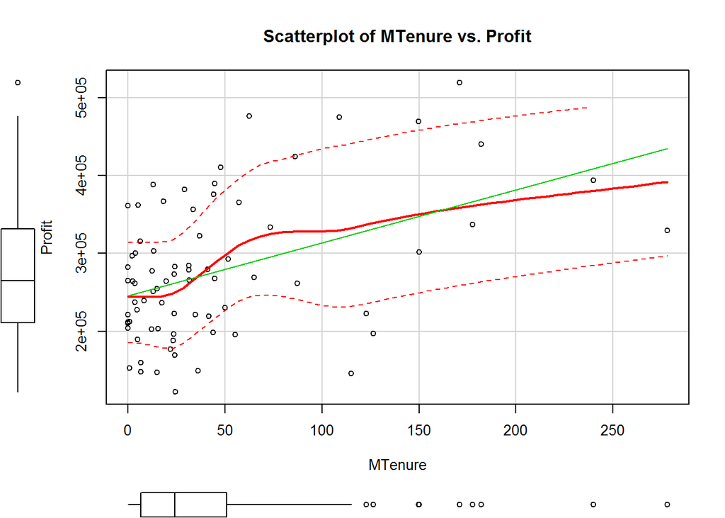

```r
scatterplot(Profit~MTenure,data=store,xlab="MTenure",
            ylab="Profit",main="Scatterplot of MTenure vs. Profit")
```

# Task 4h

# 7.Use R to draw a scatter plot of Profit vs. CTenure.

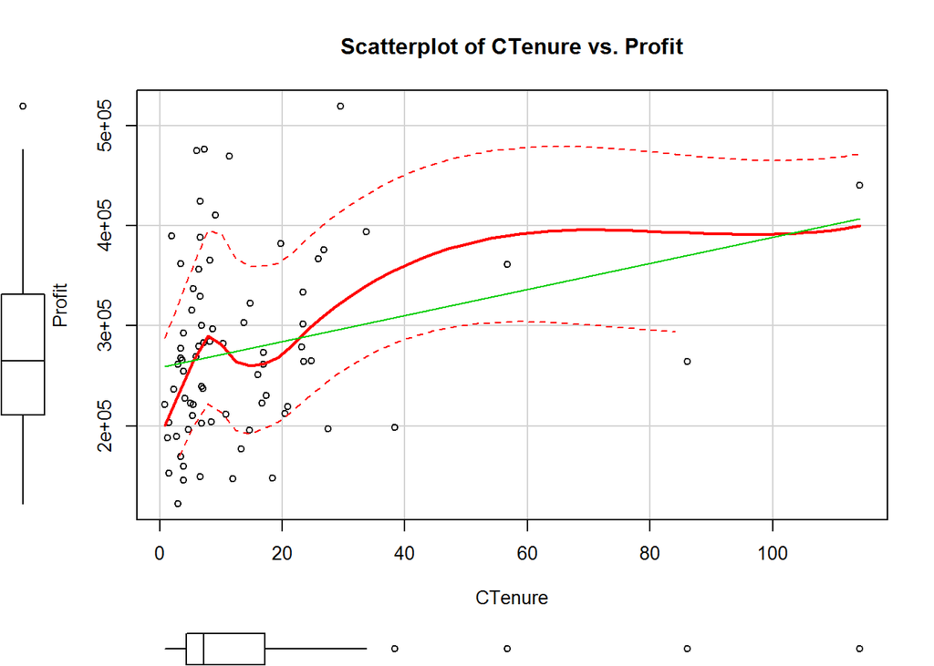

```r
scatterplot(Profit~CTenure,data=store,xlab="CTenure",
            ylab="Profit",main="Scatterplot of CTenure vs. Profit")
```

# Task 4i Correlation Matrix

# 8.Use R to construct a Correlation Matrix for all the variables in the dataset.

```r
options(digits=2)
cor(store)
```

```
##             store  Sales Profit MTenure CTenure     Pop   Comp Visibility
## store       1.000 -0.227 -0.200  -0.057  0.0199 -0.2894  0.032     -0.026
## Sales      -0.227  1.000  0.924   0.455  0.2543  0.4035 -0.235      0.131
## Profit     -0.200  0.924  1.000   0.439  0.2577  0.4306 -0.335      0.136
## MTenure    -0.057  0.455  0.439   1.000  0.2434 -0.0609  0.181      0.157
## CTenure     0.020  0.254  0.258   0.243  1.0000 -0.0015 -0.070      0.067
## Pop        -0.289  0.403  0.431  -0.061 -0.0015  1.0000 -0.268     -0.050
## Comp        0.032 -0.235 -0.335   0.181 -0.0703 -0.2683  1.000      0.028
## Visibility -0.026  0.131  0.136   0.157  0.0665 -0.0500  0.028      1.000
## PedCount   -0.221  0.424  0.450   0.062 -0.0841  0.6076 -0.146     -0.141
## Res        -0.031 -0.167 -0.159  -0.062 -0.3403 -0.2369  0.219      0.022
## Hours24     0.027  0.063 -0.026  -0.165  0.0729 -0.2218  0.130      0.047
## CrewSkill   0.049  0.164  0.160   0.102  0.2572  0.2828 -0.042     -0.197
## MgrSkill   -0.072  0.312  0.323   0.230  0.1240  0.0836  0.224      0.073
## ServQual   -0.322  0.386  0.362   0.182  0.0812  0.1239  0.018      0.210
##            PedCount    Res Hours24 CrewSkill MgrSkill ServQual
## store       -0.2212 -0.031   0.027     0.049   -0.072  -0.3225
## Sales        0.4239 -0.167   0.063     0.164    0.312   0.3864
## Profit       0.4502 -0.159  -0.026     0.160    0.323   0.3625
## MTenure      0.0620 -0.062  -0.165     0.102    0.230   0.1817
## CTenure     -0.0841 -0.340   0.073     0.257    0.124   0.0812
## Pop          0.6076 -0.237  -0.222     0.283    0.084   0.1239
## Comp        -0.1463  0.219   0.130    -0.042    0.224   0.0181
## Visibility  -0.1411  0.022   0.047    -0.197    0.073   0.2099
## PedCount     1.0000 -0.284  -0.276     0.214    0.087  -0.0054
## Res         -0.2844  1.000  -0.089    -0.153   -0.032   0.0908
## Hours24     -0.2760 -0.089   1.000     0.105   -0.039   0.0583
## CrewSkill    0.2137 -0.153   0.105     1.000   -0.021  -0.0335
## MgrSkill     0.0875 -0.032  -0.039    -0.021    1.000   0.3567
## ServQual    -0.0054  0.091   0.058    -0.034    0.357   1.0000
```

# Task 4jCorrelations

# 9.Use R to measure the correlation between Profit and MTenure.

```r
cor(store$Profit,store$MTenure)
```

```
## [1] 0.44
```

# 10.Use R to measure the correlation between Profit and CTenure.

```r
cor(store$Profit,store$CTenure)
```

```
## [1] 0.26
```

# Task 4k

```r
library(corrgram)
```

# 11.Use R to construct the following Corrgram based on all variables in the dataset.

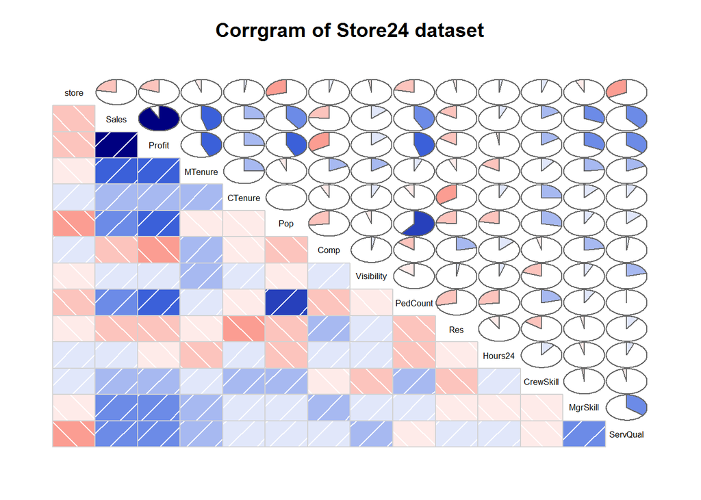

```r
corrgram(store,lower.panel=panel.shade,
         upper.panel=panel.pie,main="Corrgram of Store24 dataset")
```

# Task 4i Pearson’s Correlation Tests

# 12.Run a Pearson’s Correlation test on the correlation between Profit and MTenure. What is the p-value?

```r
cor.test(store$Profit,store$MTenure,method="pearson")
```

```
##
##  Pearson's product-moment correlation
##
## data:  store$Profit and store$MTenure
## t = 4, df = 70, p-value = 8e-05
## alternative hypothesis: true correlation is not equal to 0
## 95 percent confidence interval:
##  0.24 0.61
## sample estimates:
##  cor
## 0.44
```

P-value is 8e-05

# 13.Run a Pearson’s Correlation test on the correlation between Profit and CTenure. What is the p-value?

```r
cor.test(store$Profit,store$CTenure,method="pearson")
```

```
##
##  Pearson's product-moment correlation
##
## data:  store$Profit and store$CTenure
## t = 2, df = 70, p-value = 0.03
## alternative hypothesis: true correlation is not equal to 0
## 95 percent confidence interval:
##  0.033 0.458
## sample estimates:
##  cor
## 0.26
```

P-value is 0.03

# Task 4m Regression Analysis

# 14.Run a regression of Profit on {MTenure, CTenure Comp, Pop, PedCount, Res, Hours24, Visibility}.

```r
regr<- lm(Profit~MTenure+CTenure+Comp+Pop+PedCount+Res+Hours24+Visibility, data=store)
summary(regr)
```

```
##
## Call:
## lm(formula = Profit ~ MTenure + CTenure + Comp + Pop + PedCount +
##     Res + Hours24 + Visibility, data = store)
##
## Residuals:
##     Min      1Q  Median      3Q     Max
## -105789  -35946   -7069   33780  112390
##
## Coefficients:
##              Estimate Std. Error t value Pr(>|t|)
## (Intercept)   7610.04   66821.99    0.11  0.90967
## MTenure        760.99     127.09    5.99  9.7e-08 ***
## CTenure        944.98     421.69    2.24  0.02840 *
## Comp        -25286.89    5491.94   -4.60  1.9e-05 ***
## Pop              3.67       1.47    2.50  0.01489 *
## PedCount     34087.36    9073.20    3.76  0.00037 ***
## Res          91584.68   39231.28    2.33  0.02262 *
## Hours24      63233.31   19641.11    3.22  0.00199 **
## Visibility   12625.45    9087.62    1.39  0.16941
## ---
## Signif. codes:  0 '***' 0.001 '**' 0.01 '*' 0.05 '.' 0.1 ' ' 1
##
## Residual standard error: 57000 on 66 degrees of freedom
## Multiple R-squared:  0.638,  Adjusted R-squared:  0.594
## F-statistic: 14.5 on 8 and 66 DF,  p-value: 5.38e-12
```

# Task 4n

# 15.List the explanatory variable(s) whose beta-coefficients are statistically significant (p < 0.05).

MTenure, CTenure, Comp, Pop, PedCount, Res, Hours24

# 16.List the explanatory variable(s) whose beta-coefficients are not statistically significant (p > 0.05).

Visibility

# Task 4o

# 17.What is expected change in the Profit at a store, if the Manager’s tenure i.e. number of months of experience with Store24, increases by one month?

From the above analysis, we can decipher that if the Manager’s tenure is increased by a month, the profit changes by $760.99.

# 18.What is expected change in the Profit at a store, if the Crew’s tenure i.e. number of months of experience with Store24, increases by one month?

From the above analysis, we can decipher that if the Crew’s tenure is increased by a month, the profit changes by $944.98.

# Task 4p Executive Summary

In the case study , we read that there were discussion about the relation between Profit and tenures of Managers and Crews. Apart from various other factors as surroundings , population and competition , Managers and crew plays an important role in optimizing the profit of the store. We carried out different analysis that how profit depends on Tenure of Managers and crew.

# Overall we can say that it is a good regression model.